# R Notebook

```r
library(tidyverse)
```

Load the data again and re-familiarise yourself with it

```r
ames <- read_csv("ames.csv")
```

```
13 parsing failures.
 row     col           expected actual       file
1064 Pool.QC 1/0/T/F/TRUE/FALSE     Ex 'ames.csv'
1499 Pool.QC 1/0/T/F/TRUE/FALSE     Gd 'ames.csv'
1567 Pool.QC 1/0/T/F/TRUE/FALSE     Gd 'ames.csv'
1761 Pool.QC 1/0/T/F/TRUE/FALSE     Ex 'ames.csv'
1941 Pool.QC 1/0/T/F/TRUE/FALSE     TA 'ames.csv'
.... ....... .................. ...... ..........
See problems(...) for more details.
```

Investigate the distribution of Lot.Area. Is the distribution roughly normal? If not, what problems do you find?

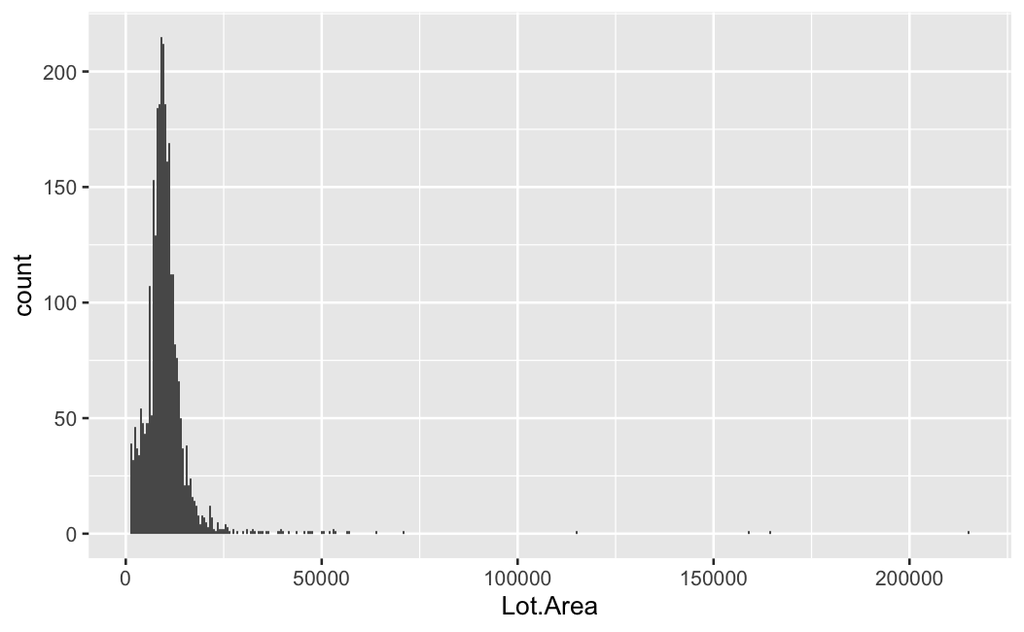

```r
ames %>%
  ggplot(aes(x = Lot.Area)) +
  geom_histogram(binwidth = 500)
```

Do you think any problematic features in the distribution of Lot.Area will cause any difficulties in estimating CIs or performing hypotheses tests using this variable? # The values with high lot area might be problematic

Compute a 95% CI for the mean Lot.Area of the sold houses.

```r
library(rcompanion)
groupwiseMean(Lot.Area ~ 1,
              data = ames,
              conf = 0.95)
```

| .id | n | Mean | Conf.level | Trad.lower | Trad.upper |
| --- | --- | --- | --- | --- | --- |
| NA | 2930 | 10100 | 0.95 | 9860 | 10400 |

You would like to know the mean Lot.Area of the sold houses with higher confidence. Calculate the 99% CI for this variable. Is it narrower or broader than the 95% CI? Does that make sense?

```r
groupwiseMean(Lot.Area ~ 1,
              data = ames,
              conf = 0.99)
```

| .id | n | Mean | Conf.level | Trad.lower | Trad.upper |
| --- | --- | --- | --- | --- | --- |
| NA | 2930 | 10100 | 0.99 | 9770 | 10500 |

Can you split out and show separate 99% CIs for mean Lot.Area grouped by House.Style? Do you see any CIs you might not trust?

```r
groupwiseMean(Lot.Area ~ House.Style,
              data = ames,
              conf = 0.99)
```

| House.Style | n | Mean | Conf.level | Trad.lower | Trad.upper |
| --- | --- | --- | --- | --- | --- |
| 1.5Fin | 314 | 10100 | 0.99 | 8220 | 12000 |
| 1.5Unf | 19 | 7060 | 0.99 | 5660 | 8450 |
| 1Story | 1481 | 10500 | 0.99 | 9910 | 11000 |
| 2.5Fin | 8 | 12500 | 0.99 | 4870 | 20100 |
| 2.5Unf | 24 | 11100 | 0.99 | 5290 | 16900 |
| 2Story | 873 | 9800 | 0.99 | 9320 | 10300 |
| SFoyer | 83 | 8210 | 0.99 | 7280 | 9150 |
| SLvl | 128 | 10500 | 0.99 | 9690 | 11300 |

# Some of the groups have very few observations 2.5Fin for example

Calculate a 99% CI for the proportion of houses in the data built before 1890. Try using the wilson and wald methods. How different are the bounds of the CIs given by the two methods?

```r
library(DescTools)
ames <- ames %>%
  mutate(build_bef_1890 = (Year.Built < 1890))

build <- table(ames$build_bef_1890)
sum <- sum(build)

BinomCI(x = build,
        n = sum,
        conf.level = 0.99,
        method = "wilson")
```

```
              est      lwr.ci      upr.ci
FALSE 0.996245734 0.992008861 0.998240217
TRUE  0.003754266 0.001759783 0.007991139
```

```r
BinomCI(x = build,
        n = sum,
        conf.level = 0.99,
        method = "wald")
```

```
              est       lwr.ci      upr.ci
FALSE 0.996245734 0.9933354922 0.999155975
TRUE  0.003754266 0.0008440246 0.006664508
```

```r
wilson_false <- 0.998240217 - 0.992008861
wilson_true <- 0.007991139 - 0.001759783
wald_false <- 0.999155975 - 0.9933354922
wald_true <- 0.006664508 - 0.0008440246
```

# both methods have similar width for the CI the wald method shows a larger distance between the upr.ci for true and lower.ci for false than wilson

do a bit of reading on the Wald and Wilson methods. Why do you think the bounds produced by the two methods are more significantly different when the proportion is closer to 0? Which method would you choose for the ‘proportion before 1890’ CI?

Calculate 95% CIs for the proportion of total house sales made up by each level of House.Style in the data

```r
levels(ames$House.Style)
```

[output not shown]

```r
obs <- table(ames$House.Style)

MultinomCI(x = obs,
           conf.level = 0.95,
           method = "wilson")
```

```
               est      lwr.ci      upr.ci
1.5Fin 0.107167235 0.096476800 0.118886391
1.5Unf 0.006484642 0.004155392 0.010106271
1Story 0.505460751 0.487362129 0.523545073
2.5Fin 0.002730375 0.001384177 0.005378786
2.5Unf 0.008191126 0.005510631 0.012159533
2Story 0.297952218 0.281665099 0.314768445
SFoyer 0.028327645 0.022910184 0.034980285
SLvl   0.043686007 0.036863320 0.051703654
```